# Galamsey by Region and District

Cumulative extent, growth, and protected-area encroachment

Published

November 6, 2026

## 1. Cumulative mining panel, by district

Same definition as `build_03_embedding_panel.R` / `explore_mining_vs_forest_type_app.js`: the **union-to-date** of `mine_mask_ghana_c4_<yr>` (monotonically non-decreasing cumulative footprint), not each year’s raw independent classification. Built, pulled by district, and written to `outputs/tables/mining_by_district.csv` / `mining_by_region.csv` by `diag_05_data_prep.R` – see that script for the EE/rgee side of this.

## 2. National total (sanity check)

```r
read_csv(here(tbl_dir, "national_check.csv"), show_col_types = FALSE) |>
  kable(digits = 1, caption = paste0("National cumulative mining through ", latest_year))
```

National cumulative mining through 2025

| method | km2 |
| --- | --- |
| sum of districts | 2429.7 |
| direct national reduceRegion | 2269.1 |

## 3. Distribution of region-level mining area, 2025

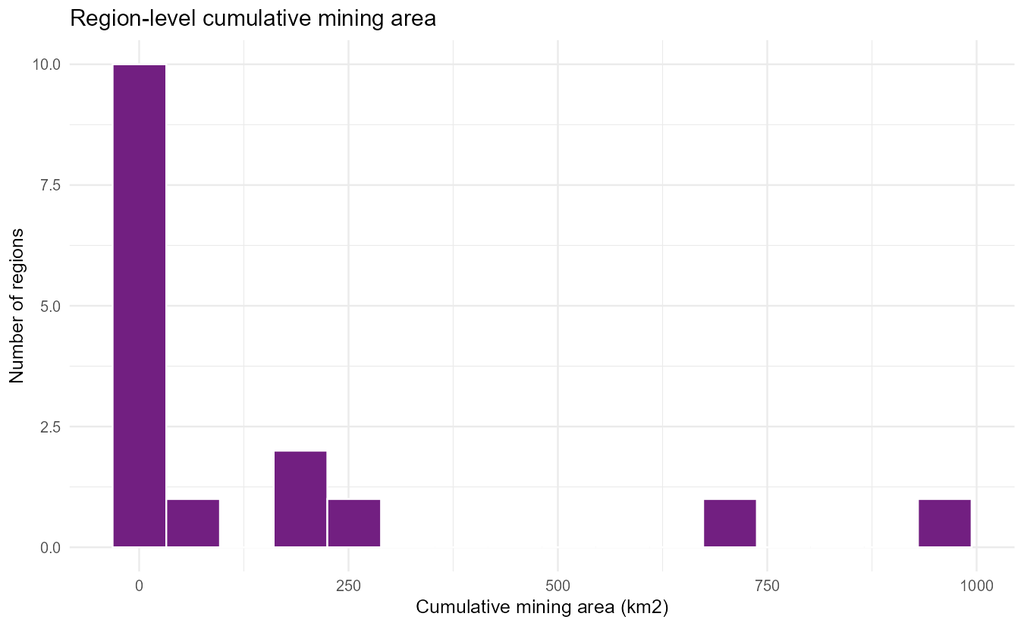

```r
knitr::include_graphics(here(fig_dir, "fig_region_hist.png"))
```

## 4. Region ranking, 2025

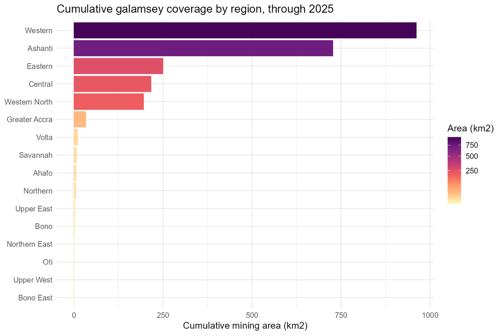

```r
knitr::include_graphics(here(fig_dir, "fig_region_bar.png"))
```

## 5. Region overview: level + growth together

Each bar’s grey segment is the 2020 level, the coloured segment is growth to 2025, so bar length = current total and the split shows how much of that total is pre-existing vs. new.

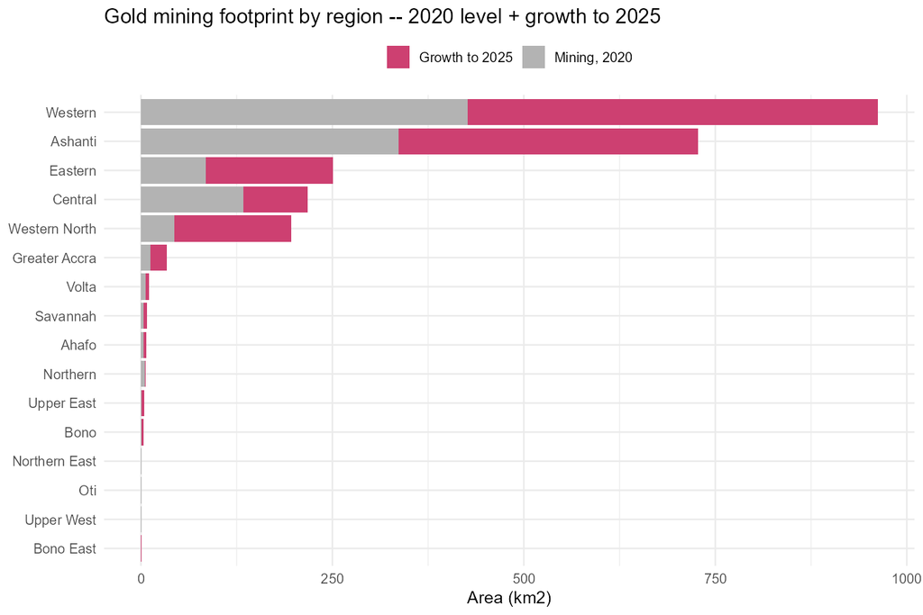

```r
knitr::include_graphics(here(fig_dir, "fig_region_overview_combined.png"))
```

## 6. Mining increase by region, 2017 -> 2025

```r
read_csv(here(tbl_dir, "region_increase.csv"), show_col_types = FALSE) |>
  kable(digits = 1, caption = paste0("Region-level mining increase, ", first_year, "-", latest_year))
```

Region-level mining increase, 2017-2025

| adm1_name | mining_first | mining_last | increase_km2 | increase_pct |
| --- | --- | --- | --- | --- |
| Western | 256.7 | 961.9 | 705.2 | 274.7 |
| Ashanti | 252.2 | 727.2 | 475.0 | 188.4 |
| Eastern | 49.7 | 250.4 | 200.7 | 403.6 |
| Western North | 19.2 | 195.9 | 176.7 | 920.4 |
| Central | 95.7 | 217.6 | 122.0 | 127.5 |
| Greater Accra | 2.8 | 34.3 | 31.5 | 1125.1 |
| Volta | 2.1 | 11.0 | 8.9 | 413.2 |
| Ahafo | 1.2 | 7.3 | 6.0 | 481.3 |
| Savannah | 2.4 | 7.9 | 5.5 | 232.7 |
| Upper East | 0.6 | 4.0 | 3.5 | 592.6 |
| Northern | 3.0 | 6.2 | 3.2 | 108.8 |
| Bono | 0.3 | 3.2 | 2.9 | 1101.7 |
| Northern East | 0.3 | 1.1 | 0.7 | 208.1 |
| Oti | 0.4 | 0.8 | 0.4 | 112.8 |
| Bono East | 0.0 | 0.4 | 0.3 | 913.8 |
| Upper West | 0.3 | 0.6 | 0.3 | 74.4 |

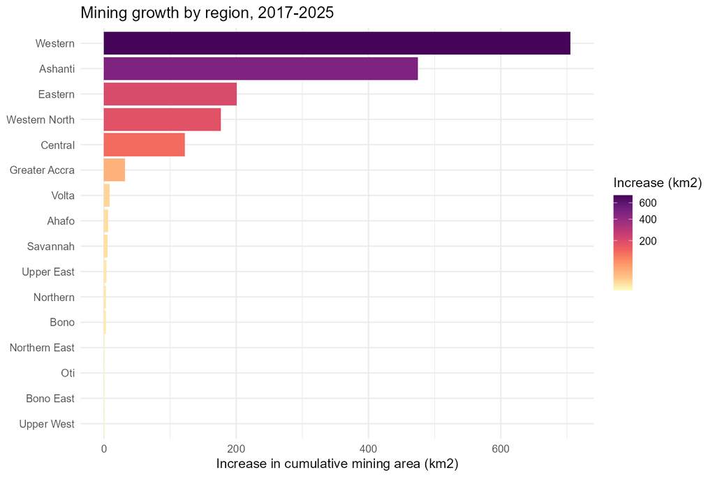

```r
knitr::include_graphics(here(fig_dir, "fig_region_increase_bar.png"))
```

## 7. Top 10 districts, 2025

Same idea one level down – which individual districts actually drive the regional totals above.

```r
read_csv(here(tbl_dir, "top10_districts.csv"), show_col_types = FALSE) |>
  kable(digits = 1, caption = paste0("Top 10 districts by cumulative mining area, ", latest_year))
```

Top 10 districts by cumulative mining area, 2025

| adm2_name | adm1_name | mining_first | mining_last | increase_km2 |
| --- | --- | --- | --- | --- |
| Wassa Amenfi East | Western | 81.0 | 250.8 | 169.8 |
| Wassa Amenfi Central | Western | 55.4 | 168.1 | 112.7 |
| Amansie Central | Ashanti | 48.2 | 164.1 | 115.9 |
| Amansie South | Ashanti | 66.5 | 134.1 | 67.6 |
| Prestea/Huni Valley | Western | 31.2 | 131.4 | 100.2 |
| Upper Denkyira West | Central | 66.2 | 127.6 | 61.4 |
| Amansie West | Ashanti | 51.2 | 121.0 | 69.8 |
| Aowin | Western North | 11.6 | 112.0 | 100.3 |
| Wassa Amenfi West | Western | 26.7 | 105.1 | 78.4 |
| Tarkwa Nsuaem | Western | 11.2 | 86.6 | 75.4 |

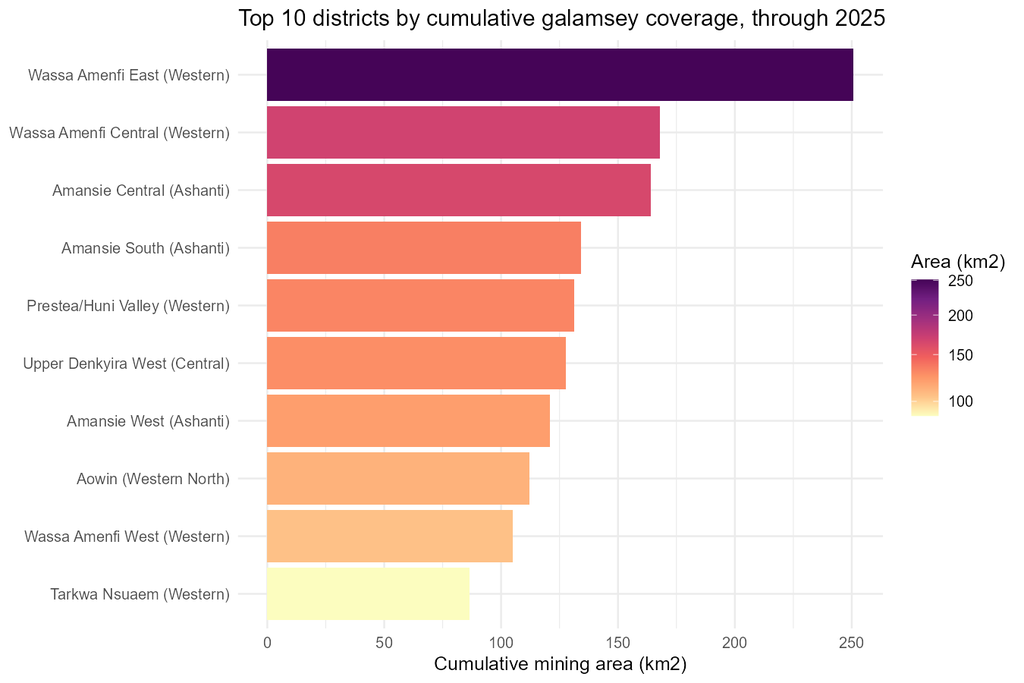

```r
knitr::include_graphics(here(fig_dir, "fig_top10_districts_bar.png"))
```

## 8. Mining encroachment on protected areas, 2025

How much of each district’s cumulative gold mining footprint falls inside a WDPA/WDOECM **Designated** protected area (national parks, forest reserves, etc. – “Proposed” sites excluded, not yet legally protected).

```r
pa_summary <- read_csv(here(tbl_dir, "national_pa_summary.csv"), show_col_types = FALSE)
cat(sprintf(
  "National: %.1f km2 (%.1f%%) of cumulative gold mining through %d falls inside a Designated protected area.\n",
  pa_summary$nat_mining_in_pa, pa_summary$pct_mining_in_pa, pa_summary$year))
```

National: 121.7 km2 (5.0%) of cumulative gold mining through 2025 falls inside a Designated protected area.

```r
read_csv(here(tbl_dir, "protected_overlap_top15.csv"), show_col_types = FALSE) |>
  kable(digits = 1, caption = paste0(
    "Top 15 districts by gold mining area inside a Designated protected area, through ", latest_year))
```

Top 15 districts by gold mining area inside a Designated protected area, through 2025

| adm2_name | adm1_name | mining_total | mining_in_pa | pa_area | pct_mining_in_pa |
| --- | --- | --- | --- | --- | --- |
| Amansie Central | Ashanti | 164.1 | 26.9 | 136.6 | 16.4 |
| Wassa Amenfi East | Western | 250.8 | 15.1 | 408.6 | 6.0 |
| Wassa Amenfi Central | Western | 168.1 | 8.7 | 505.6 | 5.2 |
| Amansie West | Ashanti | 121.0 | 6.8 | 42.8 | 5.6 |
| Bibiani-Anhwiaso-Bekwai Municipal | Western North | 24.9 | 6.2 | 262.3 | 24.8 |
| Amansie South | Ashanti | 134.1 | 6.1 | 145.9 | 4.5 |
| Prestea/Huni Valley | Western | 131.4 | 5.6 | 295.4 | 4.2 |
| Tarkwa Nsuaem | Western | 86.6 | 5.5 | 137.7 | 6.4 |
| Aowin | Western North | 112.0 | 5.5 | 1287.6 | 4.9 |
| Suaman | Western North | 20.7 | 4.8 | 184.4 | 23.1 |
| Wassa East | Western | 31.3 | 3.1 | 752.2 | 9.8 |
| Adansi Akrofuom | Ashanti | 50.9 | 3.0 | 128.8 | 5.8 |
| Atwima Mponua | Ashanti | 76.3 | 2.8 | 591.3 | 3.7 |
| Anloga | Volta | 2.4 | 2.3 | 232.2 | 95.5 |
| Mpohor | Western | 30.2 | 1.9 | 29.2 | 6.4 |

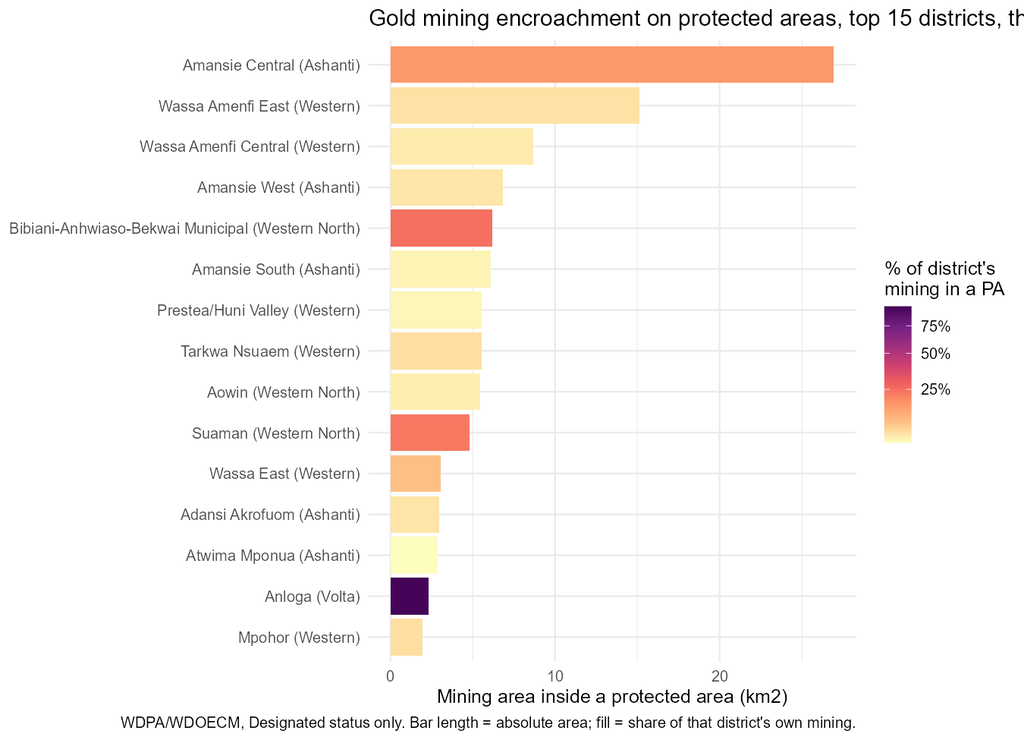

```r
knitr::include_graphics(here(fig_dir, "fig_protected_areas_bar.png"))
```